# ISSS608: AY2021-22(T2) Take-Home Exercise 1

Using ggplot2 to prepare two sets of data visualisations.

Melissa Tan (SMU MITB Analytics Track)https://scis.smu.edu.sg/master-it-business/analytics-track/curriculum?gclid=CjwKCAiA3L6PBhBvEiwAINlJ9EJwYxpaZv-zPxR0UMntDh37TrlWU7jwXP9Dcu9jvWvN8uEJsOWzTRoCqrQQAvD_BwE  
2022-02-16

# Data Preparation in R

For both visualisations, data extraction and wrangling were done in R using the *tidyverse* suite of packages. An additional *readxl* package was also installed to import the Superstore dataset (stored in Excel format) as it was not part of the *tidyverse* suite. The *knitr* package was used to allow dataframe tables to be displayed.

```r
packages = c('tidyverse', 'readxl', 'knitr')

for(p in packages){
  if(!require(p, character.only = T)){
    install.packages(p)
  }
  library(p, character.only = T)
}
```

# Visualisation 1: Pareto Chart

First, the relevant data were imported into the R environment. As the required data were stored in different Excel worksheets, a new dataframe, *joined_tab* was created by using the *left_join()* function matched by each row’s unique **Order ID**.

```r
orders <- read_xls("data/Superstore-2021.xls",
                  sheet = "Orders")
returns <- read_xls("data/Superstore-2021.xls",
                  sheet = "Returns")

joined_tab <- left_join(returns, orders,
                        by = c('Order ID' = 'Order ID'))
```

Next, the *group_by()* method was used to group the same **Sub-Category** items together, and *summarise()* was used to compute the count of **Returns** for each Sub-Category.

```r
freq_returned <- joined_tab %>%
  group_by(`Sub-Category`) %>%
  summarise('Returns' = n()) %>%
  ungroup()
```

To calculate the **cumulative frequency**, the items were sorted in order of decreasing frequency by using *arrange(desc())*, and a new dataframe column **cumfreq** was created to store the cumulative sum of **Returns**.

| Sub-Category | Returns | cumfreq |
| --- | --- | --- |
| Binders | 552 | 552 |
| Paper | 487 | 1039 |
| Phones | 309 | 1348 |
| Furnishings | 266 | 1614 |
| Accessories | 251 | 1865 |
| Chairs | 238 | 2103 |
| Storage | 233 | 2336 |
| Appliances | 177 | 2513 |
| Art | 177 | 2690 |
| Tables | 116 | 2806 |
| Fasteners | 94 | 2900 |
| Labels | 80 | 2980 |
| Supplies | 69 | 3049 |
| Machines | 55 | 3104 |
| Bookcases | 51 | 3155 |
| Envelopes | 50 | 3205 |
| Copiers | 21 | 3226 |

## ggplot2 visualisation

A Pareto chart is a type of chart that contains both bars and a line graph, where individual values are represented in descending order by bars, and the cumulative total is represented by the line. While R has the *qcc* package to compute and plot such charts, for purposes of this take-home exercise, *ggplot2* was used to create the chart by appropriate layering and transformation.

First, to plot the bar chart to show the absolute frequency of returns, *geom_bar()* was used. As the default option for bar charts in ggplot is to arrange the bars in alphabetical order, *reorder()* was used to re-arrange the bars in descending order of frequency of returns (*-Returns*).

Next, to plot the cumulative frequency values in a line graph, *geom_line()* and *geom_point()* was applied.

Finally, formatting of the Pareto chart was done to improve ease of visualisation by using *theme()* e.g. using a minimalist theme, reducing the data ink of non-essential background and grid lines, and re-orientating the x-tick labels to avoid overlapping text.

The R code and the final Pareto Chart of Returns by Sub-Category is shown below:

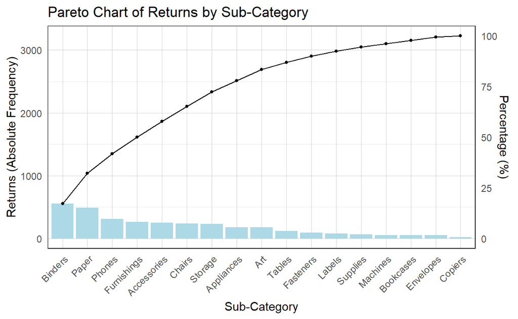

```r
ggplot(data=freq_cum, aes(x =reorder(`Sub-Category`, -`Returns`), y=`Returns`))+
  geom_bar(stat="identity", fill="lightblue")+
  geom_line(aes(y=`cumfreq`), colour = "black",size=0.5, group=1)+
  scale_y_continuous(sec.axis = sec_axis(~.*100/sum(freq_cum$Returns), name = "Percentage (%)"))+
  geom_point(aes(y=`cumfreq`), colour = "black", size=1)+
  xlab("Sub-Category") +
  ylab("Returns (Absolute Frequency)") +
  theme_minimal()+
  theme(axis.text.x = element_text(angle = 45, vjust = 1, hjust=1),
        legend.position = "none",
        panel.background = element_rect(fill = "white",
                                        colour="white",
                                        size=0.5,
                                        linetype="solid"),
        panel.grid.major = element_line(size = 0.25,
                                        linetype = 'solid',
                                        colour = "lightgrey"),
        panel.border = element_rect(colour = "black", fill=NA, size=0.5))+
  ggtitle ("Pareto Chart of Returns by Sub-Category")
```

# Visualisation 2: Population Pyramid

Once again, data from the source *csv* file was imported into the R environment by using *read_csv()*. Since only the age, gender and population fields were needed for this exercise, a new dataframe, *SGpop_gp* was created by using the *groupby()* function to group the dataset first by gender (**Sex**), then by age bracket (**AG**). The sum of the corresponding population for each group was calculated using *summarise()* and stored in the **Pop** field.

```r
SGpop <- read_csv("data/respopagesextod2021.csv")

SGpop_gp <- SGpop %>%
  group_by(`Sex`,`AG`) %>%
  summarise('Pop'=sum(`Pop`)) %>%
  ungroup()

kable(head(SGpop_gp))
```

| Sex | AG | Pop |
| --- | --- | --- |
| Females | 0_to_4 | 87730 |
| Females | 10_to_14 | 97980 |
| Females | 15_to_19 | 100190 |
| Females | 20_to_24 | 115730 |
| Females | 25_to_29 | 139780 |
| Females | 30_to_34 | 155790 |

Additional adjustments to prepare the data for the *ggplot2* graph included:

- Correcting the placement of the bars for the 5 to 9 years old age bracket
- Changing the name of the gender columns to singular forms; and
- Stipulating the order and text of the bars in *AG_new*.

Note: Replacing values in the source dataset is generally not recommended because we may not know what the data represents. However, in this specific example, it is very clear that the 5 to 9 years old age bracket should be displayed between the 0 to 4 years old and the 10 to 14 years old brackets, rather than with the 50+ age brackets. Hence, a replacement was done to resolve the issue.

```r
SGpop_gp$AG[SGpop_gp$AG=="5_to_9"] <- "05_to_9"

SGpop_gp$Sex[SGpop_gp$Sex=="Females"] <- "Female"
SGpop_gp$Sex[SGpop_gp$Sex=="Males"] <- "Male"

AG_new <- c("0-4", "5-9", "10-14","15-19","20-24","25-29","30-34","35-39","40-44","45-49","50-54","55-59","60-64","65-69","70-74","75-79","80-84","85-89","90 & over")
```

## ggplot2 visualisation

A population pyramid is a special kind of bar graph. In this instance, it displays male and female populations on side-by-side x-axes, with the 0 line down the middle.

To achieve this effect on ggplot2, the y-axis values for the **Male** population were made **negative** by applying a scalar multiplier of -1. This allows a “reflection” of the two graphs to be displayed along a common axis, separated by 0.

For the chart to display the correct labels and tick marks along the *Population* axis for both **Male** and **Female**, *scale_y_continuous()* was use to set the appropriate intervals and their respective labels such that starting from the left hand side of the chart, labels decreased in equal steps from 200 to 0 before increasing in the same steps back to 200. *scale_x_discrete()* was then used to display the age brackets correctly using the ordered list prepared in *AG_new*.

Finally, *coord_flip()* was used to display the bars horizontally, creating the familiar pyramid shape.

The R code and final population pyramid chart are shown below:

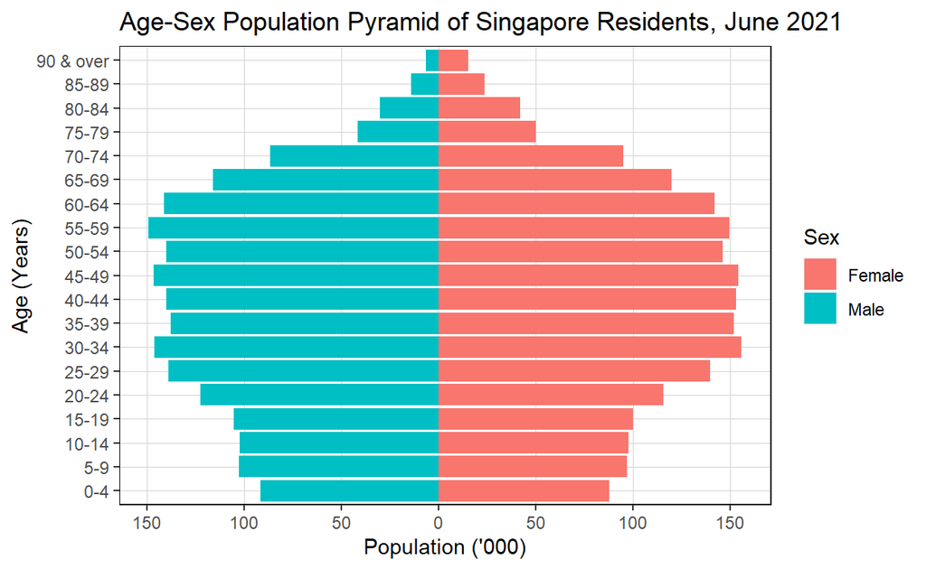

```r
ggplot(SGpop_gp, aes(x = `AG`, y = `Pop`, fill = `Sex`)) +
  geom_bar(data = subset(SGpop_gp, Sex == "Female"), stat = "identity") +
  geom_bar(data = subset(SGpop_gp, Sex == "Male"), aes(y=`Pop`*-1), stat = "identity") +
  scale_y_continuous(name="Population ('000)", breaks = seq(-200000, 200000, 50000),
                     labels = paste0(as.character(c(seq(200, 0, -50), seq(50, 200, 50))))) +
  scale_x_discrete(labels= AG_new)+
  xlab("Age (Years)")+
  coord_flip()+
  labs(title="Age-Sex Population Pyramid of Singapore Residents, June 2021")+
  theme(panel.background = element_rect(fill = "white",
                                        colour="white",
                                        size=0.5,
                                        linetype="solid"),
        panel.grid.major = element_line(size = 0.25,
                                        linetype = 'solid',
                                        colour = "lightgrey"),
        panel.border = element_rect(colour = "black", fill=NA, size=0.5))
```

# Reflections on visualising data programmatically versus using Graphical User Interface (GUI) software

It is a false dichotomy to debate whether one method is better than the other. Both programmatic data visualisation using R, and GUI software such as Tableau, have their pros and cons depending on the requirements and intent of the data analyst.

GUI software such as Tableau have the following features:

- It is very intuitive and easy to learn and use
- It is effective for visual pattern discovery
- It has beautiful out-of-the-box visualisations

However,it may be limited in its data manipulation options for complex analytics.

On the other hand, a programming language such as R:

- Has a longer learning curve and is less straightforward to use at the start
- Yet, it has the benefit of **reproducibility** and **flexibility** to incorporate other features beyond visualisations (e.g. text write-ups, displaying code chunks, creating a blog/slides etc) **all in one script**.

As a data analyst, especially one that specialises in data visualisation, it would be a good idea to develop basic familiarity with a range of GUI tools, and sufficient competency in at least one programmatic visualisation technique, so as to have the versatility to apply either or even both methods when required.

# References and Resources:

1. [R4DSA:Creating a Pareto Chart using ggplot](https://r4dsa.netlify.app/posts/2022-01-23-creating-a-pareto-chart-using-ggplot/)
2. [International Population Pyramids with ggplot2](https://rpubs.com/walkerke/pyramids_ggplot2)
3. [Why use R when you have Tableau?](https://nandeshwar.info/data-science-2/tableau-vs-r/)
4. [GUI or Coding: Production vs. Operation](https://towardsdatascience.com/guis-or-coding-production-vs-operation-fc1de9e483a8)